# Smoller Brainspan Part II

Meeta Mistry

Array analysis for Erin Dunn (erindunn@pngu.mgh.harvard.edu) at MGH. Contact Meeta Mistry (mmistry@hsph.harvard.edu) for additional details.

> In Part I, we verified that the problem of confounding variables exists within the [Kang et al](http://www.nature.com/nature/journal/v478/n7370/full/nature10523.html) developmental [expression data](http://www.ncbi.nlm.nih.gov/geo/query/acc.cgi?acc=GSE25219) that we are using. In the next stages we aim to remove the effects of confounders by applying various methods which include *isva* best described in [Teschendorff A.E. et al., 2011](http://bioinformatics.oxfordjournals.org/content/27/11/1496.long) and *RUV* (remove unwanted variation) a method described in more detail [Gagnon-Bartsch J.A., 2011](http://biostatistics.oxfordjournals.org/content/13/3/539.short).

**Note: ISVA is not included in the final HTML report but code remains in the markdown file.**

## Workflow

- Download the most up-to-date version of the GEO data
- Identify a set of negative control genes
- RUV results and interpretations
- Considerations

## Setup

### Bioconductor and R libraries used

```r
loadlibs <- function(){
library(ggplot2)
library(gtable)
library(scales)
library(RColorBrewer)
library(GEOquery)
library(affy)
library(arrayQualityMetrics)
library(reshape)
library(xtable)
library(isva)
library(limma)
library(Biobase)
library(gridExtra)
library(CHBUtils)
library(png)
library(stringr)
library(dplyr)
library(ruv)
}
suppressPackageStartupMessages(loadlibs())
```

### Set variables

```r
# Setup directory variables
baseDir <- '.'
dataDir <- file.path(baseDir, "data")
metaDir <- file.path(dataDir, "meta")
resultsDir <- file.path(baseDir, "results")
#covarsfilename <- 'covdesc.txt'
```

## Load the expression data

There are two sources of Brainspan data:

1. Link on [Brainspan](http://www.brainspan.org/static/download.html) website
2. GEO submission which is associated with the publication [Kang et al, Nature 2011](http://www.ncbi.nlm.nih.gov/pubmed/22031440)

The data available for download on the **Brainspan website is missing a large number of samples** compared to the GEO dataset. Correspondence with Ying Zhu (ying.zhu@yale.edu) from Nenad Sestan’s lab provided us with instruction to use the full dataset on GEO as opposed to the data on Brainspan. The GEO entry GSE25219 was updated since the Part I report and the most recent version of data can be downloaded from GEO GSE25219. **Data used in this report was downloaded from GEO on 10/09/2014.**

The expression data obtained from GEO has been pre-processed with RMA, quantile normalized and log2 transformed (as in Part I). The dataset contains samples from 16 different brain regions, but we focused on the orbitofrontal cortex samples for the remaining analyses in this report.

```r
# Load GEO data
gse_gene <- getGEO(filename=file.path(dataDir, 'geo/GSE25219-GPL5175_series_matrix.txt.gz'))
```

## Load the metadata and extract OFC expression data

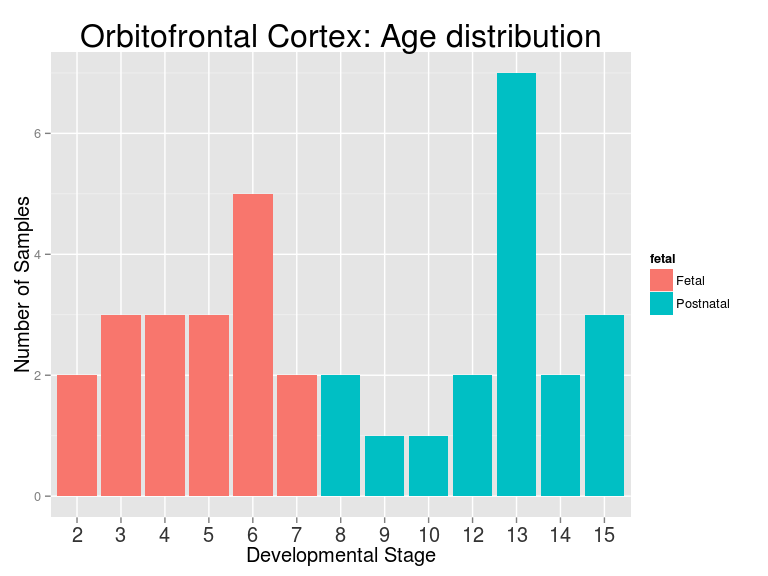

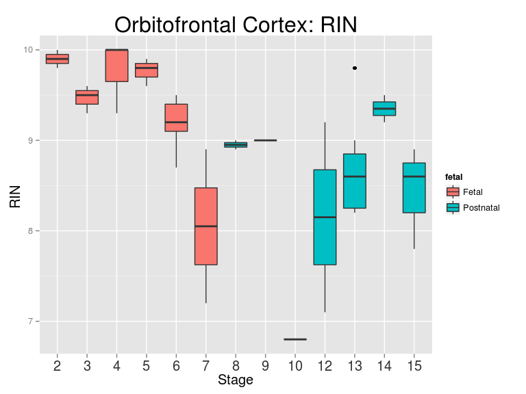

```r
pheno_gene <- read.delim(file.path(metaDir, 'brainspan_samples_metadata.txt'), row.names=1)
meta_donor <- read.delim(file.path(metaDir, 'brainspan_donor_metadata.txt'), row.names=1)

# Subset data by region and hemisphere
meta_ofc <- pheno_gene[which(pheno_gene$BrainRegion == "OFC" & pheno_gene$Hemisphere == "R"),]
meta_ofc$PMI <- as.numeric(as.character(meta_ofc$PMI))
meta_ofc$Stage <- factor(meta_ofc$Stage)

# Add data
data_ofc <- exprs(gse_gene)
data_ofc <-data_ofc[,which(colnames(data_ofc) %in% rownames(meta_ofc))]
eset.ofc <- new("ExpressionSet", exprs=data_ofc)

# Add metadata
fetal <- rep("NA", nrow(meta_ofc))
stage.num <- as.numeric(as.character(meta_ofc$Stage))
fetal[which(stage.num <= 7)] <- "Fetal"
fetal[which(stage.num > 7)] <- "Postnatal"
fetal <- factor(fetal)
meta_new <-cbind(meta_ofc, fetal)
meta_new$Stage <- stage.num

meta_new <- droplevels(meta_new)
pData(eset.ofc) <- droplevels(meta_new)
fData (eset.ofc) <- fData(gse_gene)
```

## QC: Comparing GEO versions

We are using a new version of expression data from GEO and we are unsure of what the difference is. The total number of samples is the same between versions, but perhaps there is some thing about the expression that has changed. To gain a better understanding of how the expression data may have changed from the previous version we performed a quick check of the data quality. The new data (OFC only, to stay consistent with Part I) was run through [arrayQualityMetrics](http://www.bioconductor.org/packages/release/bioc/vignettes/arrayQualityMetrics/inst/doc/arrayQualityMetrics.pdf) and diagnostic plots were compared to those generated from Part I GEO data.

Below we plotted the false color heatmaps generated from the two different GEO versions, as this is where we observed a small discrepancy. The left hand plot is the heatmap of the sample-to-sample distances between arrays in the old version. Smaller distances (in blue) indicate the samples are more similar to one another, where distances closer to 1 (yellow) suggest divergence. Patterns in the left hand plot indicate clustering of the arrays by fetal and postnatal age with the *exception of two samples*. The right hand plot shows a false color heatmap using the current (most up to date) version of the data, where the outliers no longer exist. There is definitely some change in the data as samples cluster somewhat differently, although a bit unsure of the source of change. As such, we will continue using the current version.

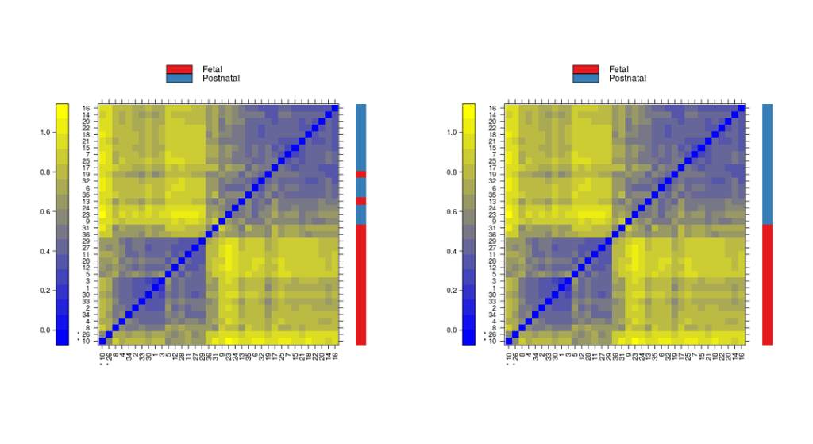

## RUV: remove unwanted variation

We next applied [RUV](http://www.stat.berkeley.edu/~johann/ruv/) to remove unwanted variation in the data - namely to see if we could remove the effects of confounding variables RIN, PMI, and other possible non-measured confounders. The strategy underlying RUV is to use negative control genes and identify a set of K surrogate variables based on the expression of those genes. These surrogate variables are incorporated into the linear model as covariates to correct for unwanted variation. The negative control genes are genes whose expression levels are known a priori to be truly unassociated with the biological factor of interest. In our case, genes that we know a priori do not change in their expression over the course of development.

Our original strategy was to use *housekeeping genes* as provided in [Eisenberg E., and Levanon E.Y.](http://www.ncbi.nlm.nih.gov/pubmed/12850439) as our list of *negative control genes*. The RUV starter analysis generates two panels of diagnostic plots, 1) for all genes that are being assayed and 2) for only the nagtive control gene set (please see the [how-to manual](http://www.stat.berkeley.edu/~johann/ruv/howto/howto.html) for step-by-step description and interpretation). These panels are generated for all levels of K specified. Using these diagnostic plots we can then determine what K is best to use (i.e how many surrogate variables to include)

### Finding a better set of negative control genes

Two factors that are adding unwanted variation in our data are RIN and PMI. A good set of negative controls would therefore be to find a set of genes that are **associated with these variables (RIN and PMI) yet unaffected by age**. In our current cohort, RIN and PMI are highly correlated with age (our primary variable of interest), so it is almost impossible to extract changes that are unique to the confounders. However, if we use only postantal samples this correlation disappears. Below we have plotted Stage on the x-axis and PMI and RIN on the y-axis for each sample in the *postnatal only cohort*.

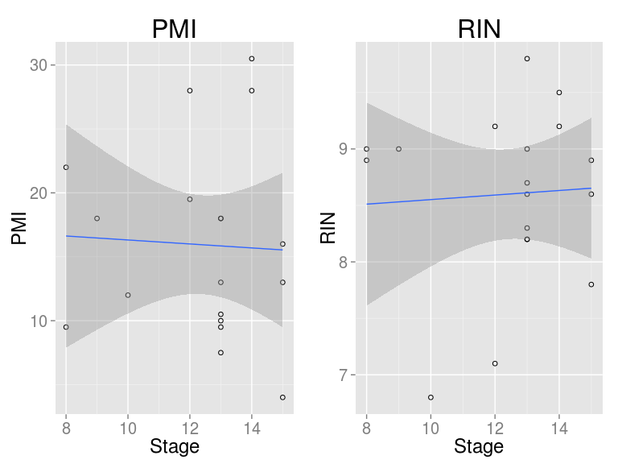

```r
# Keep only samples >= Stage 8
samples <- row.names(pData(eset.ofc))[which(pData(eset.ofc)$Stage >= 8)]
eset.nc <- eset.ofc[,samples]

# Plot relationship with Age
p1 <- ggplot(pData(eset.nc), aes(x=Stage, y=PMI)) +
  geom_point(shape=1)  +
  geom_smooth(method=lm) +  # Add linear regression line
  ggtitle('PMI') +
  theme(plot.title = element_text(size = rel(2.0)),
        axis.title = element_text(size = rel(1.5)),
        axis.text = element_text(size = rel(1.25)))

p2 <- ggplot(pData(eset.nc), aes(x=Stage, y=RIN)) +
  geom_point(shape=1)  +
  geom_smooth(method=lm) +  # Add linear regression line
  ggtitle('RIN') +
  theme(plot.title = element_text(size = rel(2.0)),
        axis.title = element_text(size = rel(1.5)),
        axis.text = element_text(size = rel(1.25)))

grid.arrange(p1, p2, ncol=2)
```

### Using ‘postnatal only’ cohort to find negative control genes

Since there is no correlation between our unwanted factors (RIN and PMI) and our primary variable of interest (Stage) in the postnatal only cohort, the gene set we identify is less likely to be age associated. We cannot be 100% sure as there still may be age/Stage related changes that across the postnatal span of life that overlap with changes with RIN and PMI.

We ran two linear models using the ‘postnatal only’ cohort, one for RIN and one for PMI. Since both are continuous variables we are essentially performing a linear regression for each probe. The resulting p-value for each probe tests the null hypothesis that the coefficient is equal to zero (no effect). A low p-value indicates that you can reject the null hypothesis and changes in the predictor’s value are related to changes in the response variable (gene expression). The p-values generated for each association test (~17,000 probes) are plotted using the histogram below. The p-value is on the x-axis, and the y-axis represents the frequency of each p-value.

Results from these analyses suggest that there are no genes that appear to differ substantially in expression as a function of PMI (plot on left). While the plot on the right suggests there is a small subset of genes that change as a function of RIN.

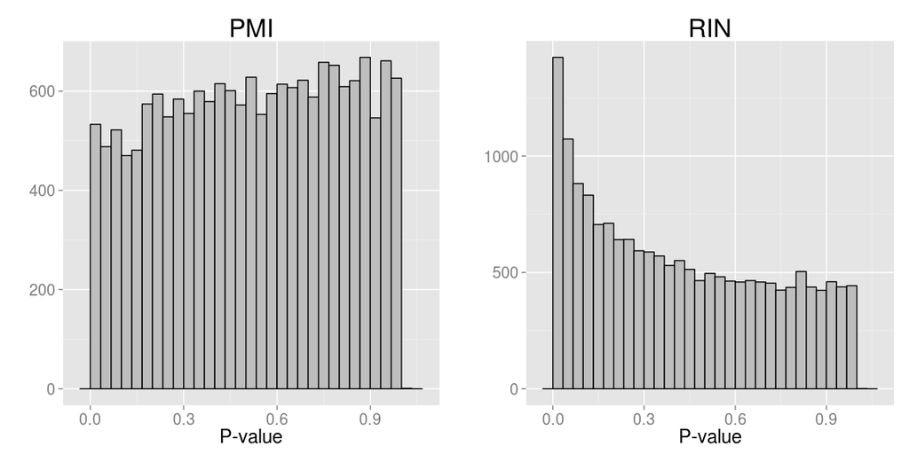

To complement the associations (or lack thereof) found via linear modeling, we also computed correlations. For each probe we measure the correlation between 1) RIN and expression and 2) PMI and expression. A histogram of correlation values are plotted below. Correlations with PMI form a narrow distribution centered around zero, indicating that most genes have little or no correlation with PMI. With RIN we see a much broader distribution of correlation values, indicating genes show a higher magnitude of association with RIN.

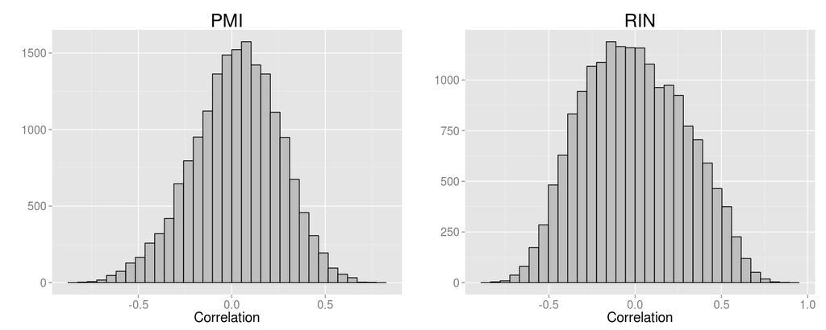

**Our new negative control set of genes is generated by selecting the top 50 genes ranked by p-values obtained from linear modeling. We will refer to this set as ‘BrainSpan negative controls’**

### Validate Brainspan negative controls

To evaluate if this new set of genes serve as ‘better’ negative controls, we need to see if and how much they are driving age/Stage related changes. To do this revert back to the expression data from the full cohort (fetal + postnatal samples) and extract only rows corresponding to our top genes. Using this subset of expression data we perform a PCA as we are interested in finding the directions (components) that maximize the variance in our dataset (right plot). Using all genes on the array (left plot) we see that there is a clear demarkation between fetal and postnatal samples (i.e the first PC is expalained by fetal versus postnatal). Using only the top RIN associated genes there is still separation of samples, but to a lesser extent.

*Note: It appears that many genes change in expression between fetal and postnatal stage of development, and finding the perfect set of negative control genes will be difficult. We may want to consider using only postnatal samples.*

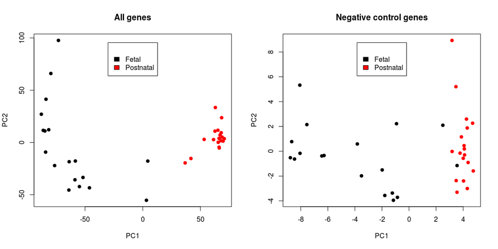

### RUV with Brainspan negative controls

We ran the RUV starter analysis as we had done previously, this time using the Brainspan negative controls rather than the housekeeping genes. Since we don’t really have a healthy mix of PMI and RIN among the patients within each stage, we also changed our primary variable from continous (Stage) to a two-group comparison (Fetal vs. Postnatal).

```r
# Get X and Y
mod <- model.matrix(~fetal, pData(eset.ofc))
X <- as.matrix(mod[,2])
Y <- t(exprs(eset.ofc))

# Assign negative control genes
ctl<-rep("FALSE", nrow(exprs(eset.ofc)))
ctl[topranked]<-"TRUE"
ctl<-as.logical(ctl)

# Extract gene information into columns
geneCol <- as.character(fData(eset.ofc)[,'gene_assignment'])
geneNames <- sapply(geneCol, function(x){strsplit(as.character(x), "//")[[1]][2]})
geneNames <- str_trim(geneNames)
geneDesc <- sapply(geneCol, function(x){strsplit(as.character(x), "//")[[1]][3]})
geneChr <- sapply(geneCol, function(x){strsplit(as.character(x), "//")[[1]][4]})
geneChr <- str_trim(geneChr)
geneinfo <- data.frame(geneNames, geneDesc, geneChr, row.names=row.names(fData(eset.ofc)))
```

```r
# A quick first look at the data
ruv_starter_analysis(Y, X, ctl, geneinfo = t(geneinfo))

# Retry and use kset to indicate specific K
ruv_starter_analysis(Y, X, ctl, geneinfo = t(geneinfo), kset=c(10:15), do_ruv4 = F, do_ruvinv = F, do_ruvrinv = F)
```

### Results and interpretation

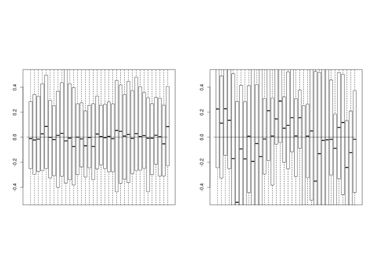

The cancor^2 of about 0.7 is, by absolute standards, very high. So while our procedure for selecting negative controls helped a bit, they are in fact still quite influenced by X. There’s another possible explanation, which is that the negative controls are good, and aren’t influenced by X, and the only reason they are correlated with X is because the unwanted variation is itself highly correlated with X.

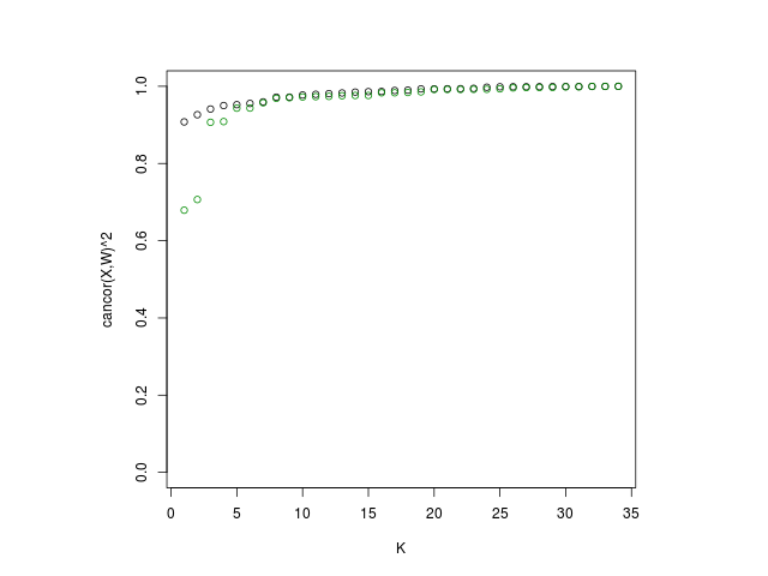

### Considerations

- RUV may not be able to remove the confounding effects if the unwanted variation is highy correlated with our primary variable of interest. RIN values correlate with X at 0.5. How high is high?
- Another method for finding negative control genes is to use genes correlated with RIN but *not* correlated with Stage. Is there anything *not* correlated with Stage?
- Incorporate positive control genes
- Try RUV-4. RUV-2 is pretty sensitive to “bad” negative controls. As for RUV-4, I’d say stick to K=1 or 2, at least for now.